# Risk Factor Analysis

## Outcome Variable

**Outcome Variable:** whz

## Predictor Variables

**Intervention Variable:** predexfd6

**Adjustment Set:**

- arm
- sex
- brthmon
- W_mage
- meducyrs
- feducyrs
- hhwealth_quart
- hfoodsec
- W_mhtcm
- W_mwtkg
- W_mbmi
- vagbrth
- W_gagebrth
- W_birthwt
- W_birthlen
- W_nrooms
- W_nchldlt5
- month
- W_parity
- impfloor
- impsan
- safeh20
- delta_W_mage
- delta_meducyrs
- delta_feducyrs
- delta_hhwealth_quart
- delta_hfoodsec
- delta_W_mhtcm
- delta_W_mwtkg
- delta_W_mbmi
- delta_vagbrth
- delta_W_gagebrth
- delta_W_birthwt
- delta_W_birthlen
- delta_W_nrooms
- delta_W_nchldlt5
- delta_month
- delta_W_parity
- delta_impfloor
- delta_impsan
- delta_safeh20

## Stratifying Variables

The analysis was stratified on these variable(s):

- agecat
- studyid
- country

## Data Summary

| agecat | studyid | country | predexfd6 | n_cell | n |
| --- | --- | --- | --- | --- | --- |
| Birth | ki0047075b-MAL-ED | BANGLADESH | 1 | 68 | 194 |
| Birth | ki0047075b-MAL-ED | BANGLADESH | 0 | 126 | 194 |
| Birth | ki0047075b-MAL-ED | BRAZIL | 1 | 5 | 57 |
| Birth | ki0047075b-MAL-ED | BRAZIL | 0 | 52 | 57 |
| Birth | ki0047075b-MAL-ED | INDIA | 1 | 4 | 37 |
| Birth | ki0047075b-MAL-ED | INDIA | 0 | 33 | 37 |
| Birth | ki0047075b-MAL-ED | NEPAL | 1 | 3 | 23 |
| Birth | ki0047075b-MAL-ED | NEPAL | 0 | 20 | 23 |
| Birth | ki0047075b-MAL-ED | PERU | 1 | 72 | 208 |
| Birth | ki0047075b-MAL-ED | PERU | 0 | 136 | 208 |
| Birth | ki0047075b-MAL-ED | SOUTH AFRICA | 1 | 1 | 90 |
| Birth | ki0047075b-MAL-ED | SOUTH AFRICA | 0 | 89 | 90 |
| Birth | ki0047075b-MAL-ED | TANZANIA, UNITED REPUBLIC OF | 1 | 0 | 105 |
| Birth | ki0047075b-MAL-ED | TANZANIA, UNITED REPUBLIC OF | 0 | 105 | 105 |
| Birth | ki1000108-CMC-V-BCS-2002 | INDIA | 1 | 7 | 7 |
| Birth | ki1000108-CMC-V-BCS-2002 | INDIA | 0 | 0 | 7 |
| Birth | ki1000108-IRC | INDIA | 1 | 0 | 12 |
| Birth | ki1000108-IRC | INDIA | 0 | 12 | 12 |
| Birth | ki1000109-EE | PAKISTAN | 1 | 24 | 28 |
| Birth | ki1000109-EE | PAKISTAN | 0 | 4 | 28 |
| Birth | ki1000304b-SAS-CompFeed | INDIA | 1 | 310 | 325 |
| Birth | ki1000304b-SAS-CompFeed | INDIA | 0 | 15 | 325 |
| Birth | ki1017093b-PROVIDE | BANGLADESH | 1 | 155 | 532 |
| Birth | ki1017093b-PROVIDE | BANGLADESH | 0 | 377 | 532 |
| Birth | ki1101329-Keneba | GAMBIA | 1 | 6 | 12 |
| Birth | ki1101329-Keneba | GAMBIA | 0 | 6 | 12 |
| Birth | ki1113344-GMS-Nepal | NEPAL | 1 | 390 | 522 |
| Birth | ki1113344-GMS-Nepal | NEPAL | 0 | 132 | 522 |
| Birth | kiGH5241-JiVitA-3 | BANGLADESH | 1 | 10161 | 13000 |
| Birth | kiGH5241-JiVitA-3 | BANGLADESH | 0 | 2839 | 13000 |

[output cut: 70 more lines]

The following strata were considered:

- agecat: 24 months, studyid: ki0047075b-MAL-ED, country: BANGLADESH
- agecat: 24 months, studyid: ki0047075b-MAL-ED, country: BRAZIL
- agecat: 24 months, studyid: ki0047075b-MAL-ED, country: INDIA
- agecat: 24 months, studyid: ki0047075b-MAL-ED, country: NEPAL
- agecat: 24 months, studyid: ki0047075b-MAL-ED, country: PERU
- agecat: 24 months, studyid: ki0047075b-MAL-ED, country: SOUTH AFRICA
- agecat: 24 months, studyid: ki0047075b-MAL-ED, country: TANZANIA, UNITED REPUBLIC OF
- agecat: 24 months, studyid: ki1000108-CMC-V-BCS-2002, country: INDIA
- agecat: 24 months, studyid: ki1000108-IRC, country: INDIA
- agecat: 24 months, studyid: ki1000109-EE, country: PAKISTAN
- agecat: 24 months, studyid: ki1017093b-PROVIDE, country: BANGLADESH
- agecat: 24 months, studyid: ki1101329-Keneba, country: GAMBIA
- agecat: 24 months, studyid: ki1113344-GMS-Nepal, country: NEPAL
- agecat: 24 months, studyid: ki1148112-LCNI-5, country: MALAWI
- agecat: 24 months, studyid: kiGH5241-JiVitA-3, country: BANGLADESH
- agecat: 24 months, studyid: kiGH5241-JiVitA-4, country: BANGLADESH
- agecat: 6 months, studyid: ki0047075b-MAL-ED, country: BANGLADESH
- agecat: 6 months, studyid: ki0047075b-MAL-ED, country: BRAZIL
- agecat: 6 months, studyid: ki0047075b-MAL-ED, country: INDIA
- agecat: 6 months, studyid: ki0047075b-MAL-ED, country: NEPAL
- agecat: 6 months, studyid: ki0047075b-MAL-ED, country: PERU
- agecat: 6 months, studyid: ki0047075b-MAL-ED, country: SOUTH AFRICA
- agecat: 6 months, studyid: ki0047075b-MAL-ED, country: TANZANIA, UNITED REPUBLIC OF
- agecat: 6 months, studyid: ki1000108-CMC-V-BCS-2002, country: INDIA
- agecat: 6 months, studyid: ki1000108-IRC, country: INDIA
- agecat: 6 months, studyid: ki1000109-EE, country: PAKISTAN
- agecat: 6 months, studyid: ki1000304b-SAS-CompFeed, country: INDIA
- agecat: 6 months, studyid: ki1000304b-SAS-FoodSuppl, country: INDIA
- agecat: 6 months, studyid: ki1017093b-PROVIDE, country: BANGLADESH
- agecat: 6 months, studyid: ki1101329-Keneba, country: GAMBIA
- agecat: 6 months, studyid: ki1113344-GMS-Nepal, country: NEPAL
- agecat: 6 months, studyid: ki1148112-LCNI-5, country: MALAWI
- agecat: 6 months, studyid: kiGH5241-JiVitA-3, country: BANGLADESH
- agecat: 6 months, studyid: kiGH5241-JiVitA-4, country: BANGLADESH
- agecat: Birth, studyid: ki0047075b-MAL-ED, country: BANGLADESH
- agecat: Birth, studyid: ki0047075b-MAL-ED, country: BRAZIL
- agecat: Birth, studyid: ki0047075b-MAL-ED, country: INDIA
- agecat: Birth, studyid: ki0047075b-MAL-ED, country: NEPAL
- agecat: Birth, studyid: ki0047075b-MAL-ED, country: PERU
- agecat: Birth, studyid: ki0047075b-MAL-ED, country: SOUTH AFRICA
- agecat: Birth, studyid: ki0047075b-MAL-ED, country: TANZANIA, UNITED REPUBLIC OF
- agecat: Birth, studyid: ki1000108-CMC-V-BCS-2002, country: INDIA
- agecat: Birth, studyid: ki1000108-IRC, country: INDIA
- agecat: Birth, studyid: ki1000109-EE, country: PAKISTAN
- agecat: Birth, studyid: ki1000304b-SAS-CompFeed, country: INDIA
- agecat: Birth, studyid: ki1017093b-PROVIDE, country: BANGLADESH
- agecat: Birth, studyid: ki1101329-Keneba, country: GAMBIA
- agecat: Birth, studyid: ki1113344-GMS-Nepal, country: NEPAL
- agecat: Birth, studyid: kiGH5241-JiVitA-3, country: BANGLADESH
- agecat: Birth, studyid: kiGH5241-JiVitA-4, country: BANGLADESH

### Dropped Strata

Some strata were dropped due to rare outcomes:

- agecat: Birth, studyid: ki0047075b-MAL-ED, country: INDIA
- agecat: Birth, studyid: ki0047075b-MAL-ED, country: NEPAL
- agecat: Birth, studyid: ki0047075b-MAL-ED, country: SOUTH AFRICA
- agecat: Birth, studyid: ki0047075b-MAL-ED, country: TANZANIA, UNITED REPUBLIC OF
- agecat: Birth, studyid: ki1000108-CMC-V-BCS-2002, country: INDIA
- agecat: Birth, studyid: ki1000108-IRC, country: INDIA
- agecat: Birth, studyid: ki1000109-EE, country: PAKISTAN
- agecat: 6 months, studyid: ki0047075b-MAL-ED, country: SOUTH AFRICA
- agecat: 6 months, studyid: ki0047075b-MAL-ED, country: TANZANIA, UNITED REPUBLIC OF
- agecat: 6 months, studyid: ki1000108-CMC-V-BCS-2002, country: INDIA
- agecat: 6 months, studyid: ki1000108-IRC, country: INDIA
- agecat: 6 months, studyid: ki1000304b-SAS-FoodSuppl, country: INDIA
- agecat: 24 months, studyid: ki0047075b-MAL-ED, country: SOUTH AFRICA
- agecat: 24 months, studyid: ki0047075b-MAL-ED, country: TANZANIA, UNITED REPUBLIC OF
- agecat: 24 months, studyid: ki1000108-CMC-V-BCS-2002, country: INDIA
- agecat: 24 months, studyid: ki1000108-IRC, country: INDIA
- agecat: 24 months, studyid: ki1000109-EE, country: PAKISTAN

## Methods Detail

We’re interested in the causal parameters $E[Y_a]$ for all values of $a \in \mathcal{A}$. These parameters represent the mean outcome if, possibly contrary to fact, we intervened to set all units to have $A=a$. Under the randomization and positivity assumptions, these are identified by the statistical parameters $\psi_a=E_W[E_{Y|A,W}(Y|A=a,W)]$. In addition, we’re interested in the mean of $Y$, $E[Y]$ under no intervention (the observed mean). We will estimate these parameters by using SuperLearner to fit the relevant likelihood factors – $E_{Y|A,W}(Y|A=a,W)$ and $p(A=a|W)$, and then updating our likelihood fit using a joint TMLE.

For unadjusted analyses ($W=\{\}$), initial likelihoods were estimated using Lrnr_glm to estimate the simple $E(Y|A)$ and Lrnr_mean to estimate $p(A)$. For adjusted analyses, a small library containing Lrnr_glmnet, Lrnr_xgboost, and Lrnr_mean was used.

Having estimated these parameters, we will then use the delta method to estimate relative risks and attributable risks relative to a prespecified baseline level of $A$.

# Results Detail

## Results Plots

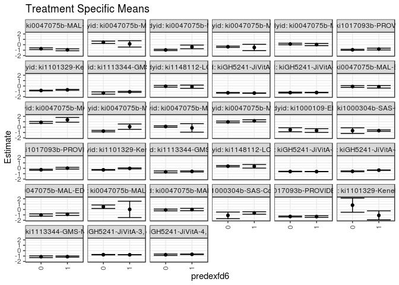

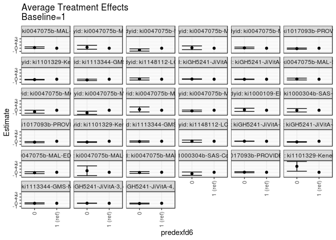

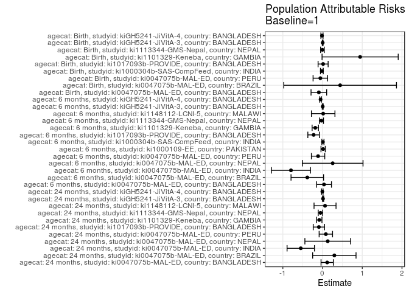

## Results Table

### Parameter: TSM

| agecat | studyid | country | intervention_level | baseline_level | estimate | ci_lower | ci_upper |
| --- | --- | --- | --- | --- | --- | --- | --- |
| Birth | ki0047075b-MAL-ED | BANGLADESH | 1 | NA | -0.8811768 | -1.1019030 | -0.6604506 |
| Birth | ki0047075b-MAL-ED | BANGLADESH | 0 | NA | -1.0232647 | -1.2283222 | -0.8182071 |
| Birth | ki0047075b-MAL-ED | BRAZIL | 1 | NA | 0.0220000 | -1.4978207 | 1.5418207 |
| Birth | ki0047075b-MAL-ED | BRAZIL | 0 | NA | 0.5069231 | 0.1803892 | 0.8334570 |
| Birth | ki0047075b-MAL-ED | PERU | 1 | NA | -0.0029575 | -0.2223254 | 0.2164103 |
| Birth | ki0047075b-MAL-ED | PERU | 0 | NA | -0.0828694 | -0.2445975 | 0.0788587 |
| Birth | ki1000304b-SAS-CompFeed | INDIA | 1 | NA | -0.6419787 | -0.8661092 | -0.4178481 |
| Birth | ki1000304b-SAS-CompFeed | INDIA | 0 | NA | -1.0901282 | -1.7027394 | -0.4775170 |
| Birth | ki1017093b-PROVIDE | BANGLADESH | 1 | NA | -1.3122180 | -1.4656916 | -1.1587444 |
| Birth | ki1017093b-PROVIDE | BANGLADESH | 0 | NA | -1.2993864 | -1.3865706 | -1.2122021 |
| Birth | ki1101329-Keneba | GAMBIA | 1 | NA | -1.0850000 | -1.9196826 | -0.2503174 |
| Birth | ki1101329-Keneba | GAMBIA | 0 | NA | 0.8066667 | -0.5095831 | 2.1229164 |
| Birth | ki1113344-GMS-Nepal | NEPAL | 1 | NA | -1.1034345 | -1.2159329 | -0.9909362 |
| Birth | ki1113344-GMS-Nepal | NEPAL | 0 | NA | -1.1185138 | -1.2774250 | -0.9596027 |
| Birth | kiGH5241-JiVitA-3 | BANGLADESH | 1 | NA | -0.7587792 | -0.7824186 | -0.7351398 |
| Birth | kiGH5241-JiVitA-3 | BANGLADESH | 0 | NA | -0.7442163 | -0.7846171 | -0.7038155 |
| Birth | kiGH5241-JiVitA-4 | BANGLADESH | 1 | NA | -0.6757635 | -0.7306420 | -0.6208850 |
| Birth | kiGH5241-JiVitA-4 | BANGLADESH | 0 | NA | -0.7515536 | -0.8838743 | -0.6192329 |
| 6 months | ki0047075b-MAL-ED | BANGLADESH | 1 | NA | -0.1587230 | -0.3930665 | 0.0756206 |
| 6 months | ki0047075b-MAL-ED | BANGLADESH | 0 | NA | -0.1025854 | -0.2688771 | 0.0637063 |
| 6 months | ki0047075b-MAL-ED | BRAZIL | 1 | NA | 1.3560666 | 0.9117292 | 1.8004040 |
| 6 months | ki0047075b-MAL-ED | BRAZIL | 0 | NA | 0.8831674 | 0.7088384 | 1.0574964 |
| 6 months | ki0047075b-MAL-ED | INDIA | 1 | NA | 0.0882753 | -0.4085073 | 0.5850580 |
| 6 months | ki0047075b-MAL-ED | INDIA | 0 | NA | -0.7378180 | -0.8715807 | -0.6040553 |
| 6 months | ki0047075b-MAL-ED | NEPAL | 1 | NA | -0.1448179 | -0.9311709 | 0.6415352 |
| 6 months | ki0047075b-MAL-ED | NEPAL | 0 | NA | 0.1158385 | -0.0230490 | 0.2547260 |
| 6 months | ki0047075b-MAL-ED | PERU | 1 | NA | 1.1677156 | 0.9675594 | 1.3678717 |
| 6 months | ki0047075b-MAL-ED | PERU | 0 | NA | 0.9691459 | 0.8154653 | 1.1228265 |
| 6 months | ki1000109-EE | PAKISTAN | 1 | NA | -0.6248062 | -0.9715960 | -0.2780164 |
| 6 months | ki1000109-EE | PAKISTAN | 0 | NA | -0.4893333 | -0.8590751 | -0.1195916 |
| 6 months | ki1000304b-SAS-CompFeed | INDIA | 1 | NA | -0.6438016 | -0.7819173 | -0.5056859 |
| 6 months | ki1000304b-SAS-CompFeed | INDIA | 0 | NA | -0.6500492 | -1.1672739 | -0.1328245 |
| 6 months | ki1017093b-PROVIDE | BANGLADESH | 1 | NA | 0.0262269 | -0.1381206 | 0.1905744 |
| 6 months | ki1017093b-PROVIDE | BANGLADESH | 0 | NA | -0.2645097 | -0.3590425 | -0.1699769 |
| 6 months | ki1101329-Keneba | GAMBIA | 1 | NA | -0.0162757 | -0.1133482 | 0.0807968 |
| 6 months | ki1101329-Keneba | GAMBIA | 0 | NA | -0.2824415 | -0.3449485 | -0.2199345 |
| 6 months | ki1113344-GMS-Nepal | NEPAL | 1 | NA | -0.5724216 | -0.6749965 | -0.4698468 |
| 6 months | ki1113344-GMS-Nepal | NEPAL | 0 | NA | -0.6574477 | -0.8286658 | -0.4862296 |
| 6 months | ki1148112-LCNI-5 | MALAWI | 1 | NA | 0.3769163 | 0.0441419 | 0.7096906 |
| 6 months | ki1148112-LCNI-5 | MALAWI | 0 | NA | 0.3964475 | 0.2692252 | 0.5236699 |
| 6 months | kiGH5241-JiVitA-3 | BANGLADESH | 1 | NA | -0.6033114 | -0.6304417 | -0.5761810 |
| 6 months | kiGH5241-JiVitA-3 | BANGLADESH | 0 | NA | -0.5901808 | -0.6360004 | -0.5443612 |
| 6 months | kiGH5241-JiVitA-4 | BANGLADESH | 1 | NA | -0.3465898 | -0.3912581 | -0.3019216 |
| 6 months | kiGH5241-JiVitA-4 | BANGLADESH | 0 | NA | -0.5616763 | -0.6418076 | -0.4815449 |
| 24 months | ki0047075b-MAL-ED | BANGLADESH | 1 | NA | -0.9342186 | -1.1141950 | -0.7542422 |
| 24 months | ki0047075b-MAL-ED | BANGLADESH | 0 | NA | -0.7328068 | -0.8927187 | -0.5728948 |
| 24 months | ki0047075b-MAL-ED | BRAZIL | 1 | NA | 0.1625323 | -0.4300600 | 0.7551246 |
| 24 months | ki0047075b-MAL-ED | BRAZIL | 0 | NA | 0.4625828 | 0.2408118 | 0.6843537 |
| 24 months | ki0047075b-MAL-ED | INDIA | 1 | NA | -0.3959949 | -0.7392829 | -0.0527070 |
| 24 months | ki0047075b-MAL-ED | INDIA | 0 | NA | -0.9599826 | -1.0840328 | -0.8359324 |
| 24 months | ki0047075b-MAL-ED | NEPAL | 1 | NA | -0.4991282 | -1.0881519 | 0.0898956 |
| 24 months | ki0047075b-MAL-ED | NEPAL | 0 | NA | -0.3663965 | -0.4865819 | -0.2462111 |
| 24 months | ki0047075b-MAL-ED | PERU | 1 | NA | 0.0378549 | -0.1605219 | 0.2362318 |
| 24 months | ki0047075b-MAL-ED | PERU | 0 | NA | 0.1442206 | -0.0041897 | 0.2926310 |
| 24 months | ki1017093b-PROVIDE | BANGLADESH | 1 | NA | -0.8003339 | -0.9634227 | -0.6372451 |
| 24 months | ki1017093b-PROVIDE | BANGLADESH | 0 | NA | -0.9268898 | -1.0211482 | -0.8326313 |
| 24 months | ki1101329-Keneba | GAMBIA | 1 | NA | -0.7196686 | -0.8024459 | -0.6368912 |
| 24 months | ki1101329-Keneba | GAMBIA | 0 | NA | -0.8457827 | -0.9071898 | -0.7843756 |
| 24 months | ki1113344-GMS-Nepal | NEPAL | 1 | NA | -1.0902107 | -1.1902132 | -0.9902081 |
| 24 months | ki1113344-GMS-Nepal | NEPAL | 0 | NA | -1.3088023 | -1.5172619 | -1.1003427 |
| 24 months | ki1148112-LCNI-5 | MALAWI | 1 | NA | -0.1391878 | -0.4356537 | 0.1572780 |
| 24 months | ki1148112-LCNI-5 | MALAWI | 0 | NA | -0.0580557 | -0.2198982 | 0.1037868 |
| 24 months | kiGH5241-JiVitA-3 | BANGLADESH | 1 | NA | -1.3228546 | -1.3580356 | -1.2876737 |
| 24 months | kiGH5241-JiVitA-3 | BANGLADESH | 0 | NA | -1.2723971 | -1.3352551 | -1.2095392 |
| 24 months | kiGH5241-JiVitA-4 | BANGLADESH | 1 | NA | -1.2205939 | -1.2608194 | -1.1803683 |
| 24 months | kiGH5241-JiVitA-4 | BANGLADESH | 0 | NA | -1.2370349 | -1.3166892 | -1.1573806 |

### Parameter: E(Y)

| agecat | studyid | country | intervention_level | baseline_level | estimate | ci_lower | ci_upper |
| --- | --- | --- | --- | --- | --- | --- | --- |
| Birth | ki0047075b-MAL-ED | BANGLADESH | NA | NA | -0.9748454 | -1.1280978 | -0.8215930 |
| Birth | ki0047075b-MAL-ED | BRAZIL | NA | NA | 0.4643860 | 0.1360519 | 0.7927200 |
| Birth | ki0047075b-MAL-ED | PERU | NA | NA | -0.0587981 | -0.1871869 | 0.0695908 |
| Birth | ki1000304b-SAS-CompFeed | INDIA | NA | NA | -0.6596308 | -0.9005716 | -0.4186900 |
| Birth | ki1017093b-PROVIDE | BANGLADESH | NA | NA | -1.2984586 | -1.3752758 | -1.2216415 |
| Birth | ki1101329-Keneba | GAMBIA | NA | NA | -0.1391667 | -1.0981858 | 0.8198525 |
| Birth | ki1113344-GMS-Nepal | NEPAL | NA | NA | -1.1064559 | -1.2034951 | -1.0094168 |
| Birth | kiGH5241-JiVitA-3 | BANGLADESH | NA | NA | -0.7557115 | -0.7768180 | -0.7346051 |
| Birth | kiGH5241-JiVitA-4 | BANGLADESH | NA | NA | -0.6904586 | -0.7435822 | -0.6373351 |
| 6 months | ki0047075b-MAL-ED | BANGLADESH | NA | NA | -0.1220707 | -0.2547831 | 0.0106417 |
| 6 months | ki0047075b-MAL-ED | BRAZIL | NA | NA | 0.9717225 | 0.8073791 | 1.1360658 |
| 6 months | ki0047075b-MAL-ED | INDIA | NA | NA | -0.7073471 | -0.8375598 | -0.5771344 |
| 6 months | ki0047075b-MAL-ED | NEPAL | NA | NA | 0.1097852 | -0.0259319 | 0.2455023 |
| 6 months | ki0047075b-MAL-ED | PERU | NA | NA | 1.0546617 | 0.9322137 | 1.1771098 |
| 6 months | ki1000109-EE | PAKISTAN | NA | NA | -0.6106944 | -0.9239621 | -0.2974268 |
| 6 months | ki1000304b-SAS-CompFeed | INDIA | NA | NA | -0.6348861 | -0.7630511 | -0.5067211 |
| 6 months | ki1017093b-PROVIDE | BANGLADESH | NA | NA | -0.1990907 | -0.2817968 | -0.1163845 |
| 6 months | ki1101329-Keneba | GAMBIA | NA | NA | -0.1997647 | -0.2531388 | -0.1463906 |
| 6 months | ki1113344-GMS-Nepal | NEPAL | NA | NA | -0.6009171 | -0.6886356 | -0.5131986 |
| 6 months | ki1148112-LCNI-5 | MALAWI | NA | NA | 0.3925000 | 0.2735307 | 0.5114693 |
| 6 months | kiGH5241-JiVitA-3 | BANGLADESH | NA | NA | -0.5998808 | -0.6237974 | -0.5759642 |
| 6 months | kiGH5241-JiVitA-4 | BANGLADESH | NA | NA | -0.3968456 | -0.4358721 | -0.3578192 |
| 24 months | ki0047075b-MAL-ED | BANGLADESH | NA | NA | -0.8179024 | -0.9399789 | -0.6958260 |
| 24 months | ki0047075b-MAL-ED | BRAZIL | NA | NA | 0.4592308 | 0.2528453 | 0.6656163 |
| 24 months | ki0047075b-MAL-ED | INDIA | NA | NA | -0.9449522 | -1.0648865 | -0.8250178 |
| 24 months | ki0047075b-MAL-ED | NEPAL | NA | NA | -0.3690411 | -0.4853679 | -0.2527143 |
| 24 months | ki0047075b-MAL-ED | PERU | NA | NA | 0.1204478 | 0.0005049 | 0.2403906 |
| 24 months | ki1017093b-PROVIDE | BANGLADESH | NA | NA | -0.8928670 | -0.9755153 | -0.8102187 |
| 24 months | ki1101329-Keneba | GAMBIA | NA | NA | -0.8032329 | -0.8532842 | -0.7531817 |
| 24 months | ki1113344-GMS-Nepal | NEPAL | NA | NA | -1.1423525 | -1.2336321 | -1.0510729 |
| 24 months | ki1148112-LCNI-5 | MALAWI | NA | NA | -0.0770652 | -0.2204213 | 0.0662909 |
| 24 months | kiGH5241-JiVitA-3 | BANGLADESH | NA | NA | -1.3113405 | -1.3420927 | -1.2805883 |
| 24 months | kiGH5241-JiVitA-4 | BANGLADESH | NA | NA | -1.2265320 | -1.2620508 | -1.1910132 |

### Parameter: ATE

| agecat | studyid | country | intervention_level | baseline_level | estimate | ci_lower | ci_upper |
| --- | --- | --- | --- | --- | --- | --- | --- |
| Birth | ki0047075b-MAL-ED | BANGLADESH | 1 | 1 | 0.0000000 | 0.0000000 | 0.0000000 |
| Birth | ki0047075b-MAL-ED | BANGLADESH | 0 | 1 | -0.1420878 | -0.4443190 | 0.1601433 |
| Birth | ki0047075b-MAL-ED | BRAZIL | 1 | 1 | 0.0000000 | 0.0000000 | 0.0000000 |
| Birth | ki0047075b-MAL-ED | BRAZIL | 0 | 1 | 0.4849231 | -1.0695798 | 2.0394260 |
| Birth | ki0047075b-MAL-ED | PERU | 1 | 1 | 0.0000000 | 0.0000000 | 0.0000000 |
| Birth | ki0047075b-MAL-ED | PERU | 0 | 1 | -0.0799119 | -0.3525499 | 0.1927261 |
| Birth | ki1000304b-SAS-CompFeed | INDIA | 1 | 1 | 0.0000000 | 0.0000000 | 0.0000000 |
| Birth | ki1000304b-SAS-CompFeed | INDIA | 0 | 1 | -0.4481495 | -0.9783682 | 0.0820692 |
| Birth | ki1017093b-PROVIDE | BANGLADESH | 1 | 1 | 0.0000000 | 0.0000000 | 0.0000000 |
| Birth | ki1017093b-PROVIDE | BANGLADESH | 0 | 1 | 0.0128316 | -0.1559991 | 0.1816624 |
| Birth | ki1101329-Keneba | GAMBIA | 1 | 1 | 0.0000000 | 0.0000000 | 0.0000000 |
| Birth | ki1101329-Keneba | GAMBIA | 0 | 1 | 1.8916667 | 0.3330748 | 3.4502585 |
| Birth | ki1113344-GMS-Nepal | NEPAL | 1 | 1 | 0.0000000 | 0.0000000 | 0.0000000 |
| Birth | ki1113344-GMS-Nepal | NEPAL | 0 | 1 | -0.0150793 | -0.1990612 | 0.1689026 |
| Birth | kiGH5241-JiVitA-3 | BANGLADESH | 1 | 1 | 0.0000000 | 0.0000000 | 0.0000000 |
| Birth | kiGH5241-JiVitA-3 | BANGLADESH | 0 | 1 | 0.0145629 | -0.0305667 | 0.0596925 |
| Birth | kiGH5241-JiVitA-4 | BANGLADESH | 1 | 1 | 0.0000000 | 0.0000000 | 0.0000000 |
| Birth | kiGH5241-JiVitA-4 | BANGLADESH | 0 | 1 | -0.0757901 | -0.2151778 | 0.0635976 |
| 6 months | ki0047075b-MAL-ED | BANGLADESH | 1 | 1 | 0.0000000 | 0.0000000 | 0.0000000 |
| 6 months | ki0047075b-MAL-ED | BANGLADESH | 0 | 1 | 0.0561376 | -0.2318016 | 0.3440768 |
| 6 months | ki0047075b-MAL-ED | BRAZIL | 1 | 1 | 0.0000000 | 0.0000000 | 0.0000000 |
| 6 months | ki0047075b-MAL-ED | BRAZIL | 0 | 1 | -0.4728992 | -0.9485535 | 0.0027552 |
| 6 months | ki0047075b-MAL-ED | INDIA | 1 | 1 | 0.0000000 | 0.0000000 | 0.0000000 |
| 6 months | ki0047075b-MAL-ED | INDIA | 0 | 1 | -0.8260934 | -1.3398208 | -0.3123659 |
| 6 months | ki0047075b-MAL-ED | NEPAL | 1 | 1 | 0.0000000 | 0.0000000 | 0.0000000 |
| 6 months | ki0047075b-MAL-ED | NEPAL | 0 | 1 | 0.2606564 | -0.5405487 | 1.0618615 |
| 6 months | ki0047075b-MAL-ED | PERU | 1 | 1 | 0.0000000 | 0.0000000 | 0.0000000 |
| 6 months | ki0047075b-MAL-ED | PERU | 0 | 1 | -0.1985696 | -0.4517775 | 0.0546382 |
| 6 months | ki1000109-EE | PAKISTAN | 1 | 1 | 0.0000000 | 0.0000000 | 0.0000000 |
| 6 months | ki1000109-EE | PAKISTAN | 0 | 1 | 0.1354729 | -0.3714513 | 0.6423970 |
| 6 months | ki1000304b-SAS-CompFeed | INDIA | 1 | 1 | 0.0000000 | 0.0000000 | 0.0000000 |
| 6 months | ki1000304b-SAS-CompFeed | INDIA | 0 | 1 | -0.0062476 | -0.5560776 | 0.5435824 |
| 6 months | ki1017093b-PROVIDE | BANGLADESH | 1 | 1 | 0.0000000 | 0.0000000 | 0.0000000 |
| 6 months | ki1017093b-PROVIDE | BANGLADESH | 0 | 1 | -0.2907366 | -0.4793857 | -0.1020874 |
| 6 months | ki1101329-Keneba | GAMBIA | 1 | 1 | 0.0000000 | 0.0000000 | 0.0000000 |
| 6 months | ki1101329-Keneba | GAMBIA | 0 | 1 | -0.2661658 | -0.3806464 | -0.1516851 |
| 6 months | ki1113344-GMS-Nepal | NEPAL | 1 | 1 | 0.0000000 | 0.0000000 | 0.0000000 |
| 6 months | ki1113344-GMS-Nepal | NEPAL | 0 | 1 | -0.0850260 | -0.2847192 | 0.1146672 |
| 6 months | ki1148112-LCNI-5 | MALAWI | 1 | 1 | 0.0000000 | 0.0000000 | 0.0000000 |
| 6 months | ki1148112-LCNI-5 | MALAWI | 0 | 1 | 0.0195312 | -0.3369857 | 0.3760482 |
| 6 months | kiGH5241-JiVitA-3 | BANGLADESH | 1 | 1 | 0.0000000 | 0.0000000 | 0.0000000 |
| 6 months | kiGH5241-JiVitA-3 | BANGLADESH | 0 | 1 | 0.0131305 | -0.0389053 | 0.0651664 |
| 6 months | kiGH5241-JiVitA-4 | BANGLADESH | 1 | 1 | 0.0000000 | 0.0000000 | 0.0000000 |
| 6 months | kiGH5241-JiVitA-4 | BANGLADESH | 0 | 1 | -0.2150864 | -0.3059600 | -0.1242128 |
| 24 months | ki0047075b-MAL-ED | BANGLADESH | 1 | 1 | 0.0000000 | 0.0000000 | 0.0000000 |
| 24 months | ki0047075b-MAL-ED | BANGLADESH | 0 | 1 | 0.2014119 | -0.0389796 | 0.4418033 |
| 24 months | ki0047075b-MAL-ED | BRAZIL | 1 | 1 | 0.0000000 | 0.0000000 | 0.0000000 |
| 24 months | ki0047075b-MAL-ED | BRAZIL | 0 | 1 | 0.3000505 | -0.3305277 | 0.9306286 |
| 24 months | ki0047075b-MAL-ED | INDIA | 1 | 1 | 0.0000000 | 0.0000000 | 0.0000000 |
| 24 months | ki0047075b-MAL-ED | INDIA | 0 | 1 | -0.5639877 | -0.9285772 | -0.1993981 |
| 24 months | ki0047075b-MAL-ED | NEPAL | 1 | 1 | 0.0000000 | 0.0000000 | 0.0000000 |
| 24 months | ki0047075b-MAL-ED | NEPAL | 0 | 1 | 0.1327316 | -0.4683661 | 0.7338293 |
| 24 months | ki0047075b-MAL-ED | PERU | 1 | 1 | 0.0000000 | 0.0000000 | 0.0000000 |
| 24 months | ki0047075b-MAL-ED | PERU | 0 | 1 | 0.1063657 | -0.1367647 | 0.3494961 |
| 24 months | ki1017093b-PROVIDE | BANGLADESH | 1 | 1 | 0.0000000 | 0.0000000 | 0.0000000 |
| 24 months | ki1017093b-PROVIDE | BANGLADESH | 0 | 1 | -0.1265559 | -0.3125215 | 0.0594097 |
| 24 months | ki1101329-Keneba | GAMBIA | 1 | 1 | 0.0000000 | 0.0000000 | 0.0000000 |
| 24 months | ki1101329-Keneba | GAMBIA | 0 | 1 | -0.1261141 | -0.2279215 | -0.0243068 |
| 24 months | ki1113344-GMS-Nepal | NEPAL | 1 | 1 | 0.0000000 | 0.0000000 | 0.0000000 |
| 24 months | ki1113344-GMS-Nepal | NEPAL | 0 | 1 | -0.2185916 | -0.4500370 | 0.0128539 |
| 24 months | ki1148112-LCNI-5 | MALAWI | 1 | 1 | 0.0000000 | 0.0000000 | 0.0000000 |
| 24 months | ki1148112-LCNI-5 | MALAWI | 0 | 1 | 0.0811321 | -0.2570480 | 0.4193123 |
| 24 months | kiGH5241-JiVitA-3 | BANGLADESH | 1 | 1 | 0.0000000 | 0.0000000 | 0.0000000 |
| 24 months | kiGH5241-JiVitA-3 | BANGLADESH | 0 | 1 | 0.0504575 | -0.0212731 | 0.1221881 |
| 24 months | kiGH5241-JiVitA-4 | BANGLADESH | 1 | 1 | 0.0000000 | 0.0000000 | 0.0000000 |
| 24 months | kiGH5241-JiVitA-4 | BANGLADESH | 0 | 1 | -0.0164410 | -0.1039501 | 0.0710680 |

### Parameter: PAR

| agecat | studyid | country | intervention_level | baseline_level | estimate | ci_lower | ci_upper |
| --- | --- | --- | --- | --- | --- | --- | --- |
| Birth | ki0047075b-MAL-ED | BANGLADESH | 1 | NA | -0.0936685 | -0.2903407 | 0.1030036 |
| Birth | ki0047075b-MAL-ED | BRAZIL | 1 | NA | 0.4423860 | -0.9762121 | 1.8609840 |
| Birth | ki0047075b-MAL-ED | PERU | 1 | NA | -0.0558406 | -0.2390376 | 0.1273565 |
| Birth | ki1000304b-SAS-CompFeed | INDIA | 1 | NA | -0.0176521 | -0.0527130 | 0.0174088 |
| Birth | ki1017093b-PROVIDE | BANGLADESH | 1 | NA | 0.0137594 | -0.1127904 | 0.1403091 |
| Birth | ki1101329-Keneba | GAMBIA | 1 | NA | 0.9458333 | -0.0131858 | 1.9048525 |
| Birth | ki1113344-GMS-Nepal | NEPAL | 1 | NA | -0.0030214 | -0.0492021 | 0.0431593 |
| Birth | kiGH5241-JiVitA-3 | BANGLADESH | 1 | NA | 0.0030677 | -0.0067698 | 0.0129051 |
| Birth | kiGH5241-JiVitA-4 | BANGLADESH | 1 | NA | -0.0146951 | -0.0421396 | 0.0127493 |
| 6 months | ki0047075b-MAL-ED | BANGLADESH | 1 | NA | 0.0366523 | -0.1507987 | 0.2241033 |
| 6 months | ki0047075b-MAL-ED | BRAZIL | 1 | NA | -0.3843441 | -0.7942472 | 0.0255591 |
| 6 months | ki0047075b-MAL-ED | INDIA | 1 | NA | -0.7956224 | -1.2878671 | -0.3033778 |
| 6 months | ki0047075b-MAL-ED | NEPAL | 1 | NA | 0.2546030 | -0.5094405 | 1.0186466 |
| 6 months | ki0047075b-MAL-ED | PERU | 1 | NA | -0.1130538 | -0.2814006 | 0.0552929 |
| 6 months | ki1000109-EE | PAKISTAN | 1 | NA | 0.0141118 | -0.0400020 | 0.0682256 |
| 6 months | ki1000304b-SAS-CompFeed | INDIA | 1 | NA | 0.0089155 | -0.0178262 | 0.0356572 |
| 6 months | ki1017093b-PROVIDE | BANGLADESH | 1 | NA | -0.2253175 | -0.3706095 | -0.0800256 |
| 6 months | ki1101329-Keneba | GAMBIA | 1 | NA | -0.1834889 | -0.2633431 | -0.1036348 |
| 6 months | ki1113344-GMS-Nepal | NEPAL | 1 | NA | -0.0284955 | -0.0801838 | 0.0231928 |
| 6 months | ki1148112-LCNI-5 | MALAWI | 1 | NA | 0.0155837 | -0.2805852 | 0.3117526 |
| 6 months | kiGH5241-JiVitA-3 | BANGLADESH | 1 | NA | 0.0034306 | -0.0084381 | 0.0152992 |
| 6 months | kiGH5241-JiVitA-4 | BANGLADESH | 1 | NA | -0.0502558 | -0.0715999 | -0.0289117 |
| 24 months | ki0047075b-MAL-ED | BANGLADESH | 1 | NA | 0.1163162 | -0.0385330 | 0.2711654 |
| 24 months | ki0047075b-MAL-ED | BRAZIL | 1 | NA | 0.2966985 | -0.2493048 | 0.8427018 |
| 24 months | ki0047075b-MAL-ED | INDIA | 1 | NA | -0.5489572 | -0.8939943 | -0.2039201 |
| 24 months | ki0047075b-MAL-ED | NEPAL | 1 | NA | 0.1300871 | -0.4451978 | 0.7053719 |
| 24 months | ki0047075b-MAL-ED | PERU | 1 | NA | 0.0825928 | -0.0861686 | 0.2513543 |
| 24 months | ki1017093b-PROVIDE | BANGLADESH | 1 | NA | -0.0925331 | -0.2352156 | 0.0501493 |
| 24 months | ki1101329-Keneba | GAMBIA | 1 | NA | -0.0835643 | -0.1513252 | -0.0158035 |
| 24 months | ki1113344-GMS-Nepal | NEPAL | 1 | NA | -0.0521418 | -0.1089981 | 0.0047144 |
| 24 months | ki1148112-LCNI-5 | MALAWI | 1 | NA | 0.0621226 | -0.2147822 | 0.3390275 |
| 24 months | kiGH5241-JiVitA-3 | BANGLADESH | 1 | NA | 0.0115142 | -0.0048482 | 0.0278765 |
| 24 months | kiGH5241-JiVitA-4 | BANGLADESH | 1 | NA | -0.0059382 | -0.0249864 | 0.0131101 |